# Bubbles in a Secular Stagnation Economy

An Abridged Model Replication

Author

Jason Lu

## 1 Introduction

Eggertsson & Mehrotra (2014) construct a three-period overlapping generations model in which a tightening of borrowing constraints permanently depresses the natural rate of interest below zero, trapping the economy at the zero lower bound. Lu (2015) extends this framework to show that a rational asset price bubble can restore the natural rate, raise output, and re-anchor inflation — but at the risk of economic instability.

## 2 Model

### 2.1 Households

Three generations coexist each period: young ($y$), middle-aged ($m$), and old ($o$). The young borrow up to a collateral limit $D$ against future middle-aged income $Y_m$. The middle-aged save. The old dissave. Market clearing in the loan market requires:

$$D = \frac{\beta(Y_m - D)}{1 + r^f}$$

### 2.2 Bubble sustainability

A rational bubble of size $A$ is sustainable if and only if it does not exceed the saving capacity of the middle-aged net of debt repayment:

$$0 \leq A \leq \bar{A}, \qquad
\bar{A} = \frac{\beta Y_m - (1+2\beta)D}{1+\beta}$$

### 2.3 Production side

Output is determined by a standard New Keynesian AS/AD system. At the ZLB the nominal rate is fixed at $i = 0$; the Taylor rule is suspended and inflation falls below target.

**AS curve:**
$$\pi_t = \kappa(Y_t - Y^f) + \beta \pi_{t+1}$$

**AD curve (ZLB):**
$$Y_t = Y_{t+1} - \sigma(i_t - \pi_{t+1} - r^n)$$

## 3 Secular Stagnation

A tightening of the borrowing constraint from $D_H$ to $D_L$ permanently reduces the natural rate. With EM (2014) Table 1 parameters:

```
Natural rate at D_H = 0.28: r^f = 0.0727 (7.27%)
Natural rate at D_L = 0.259: r^f = -0.0358 (-3.58%)
ZLB binds at D_L: True
```

**Proposition 1 (Eggertsson & Mehrotra 2014).** If $r^f(D_L) < 0$ the ZLB binds, monetary policy cannot restore full employment, and the economy settles at $Y < Y^f$ with $\pi < \pi^*$.

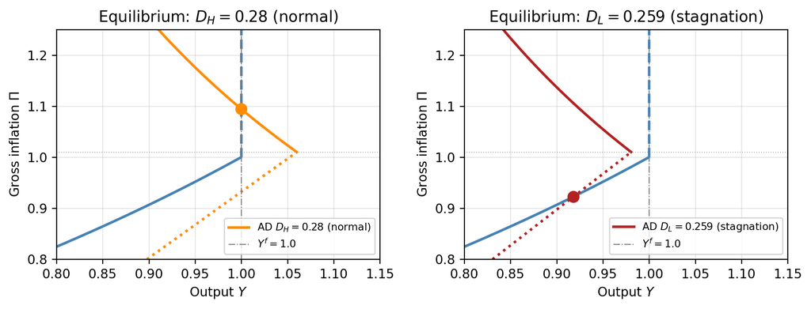

AS/AD equilibrium: normal regime (D_H) vs secular stagnation (D_L)

## 4 Bubble Restoration

```
A_max at D_L = 0.259: 0.0634
A_max/2 = 0.0317
```

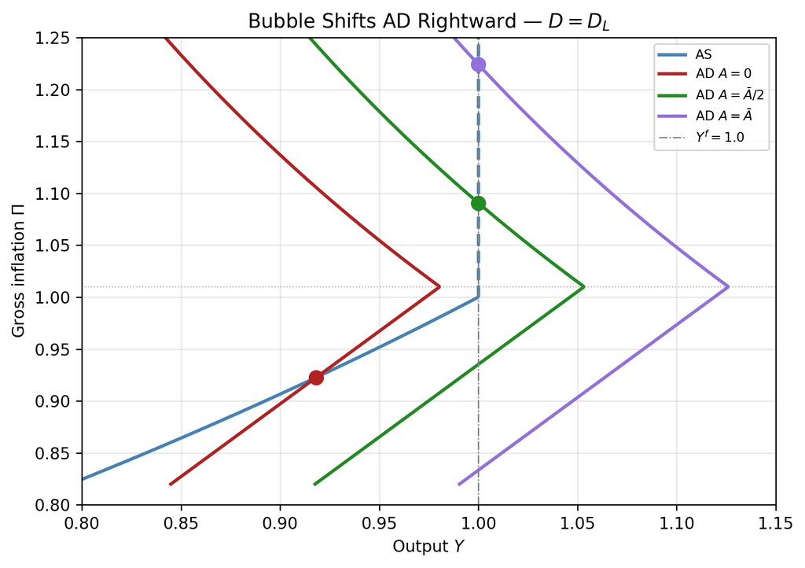

Bubble effect on AS/AD (Lu 2015 Figure 3)

## 5 Stability

The bubble is fragile. A sufficiently large adverse shock to $D$ or $Y_m$ causes the bubble to violate the sustainability condition, forcing $A \to 0$ and collapsing output back to the stagnation equilibrium.

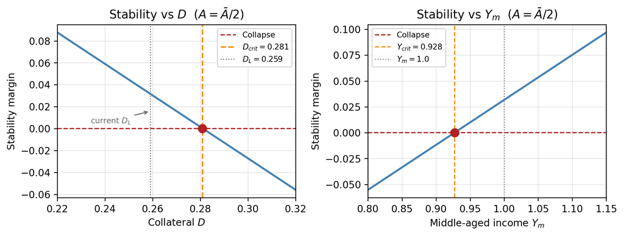

Critical shock thresholds (Lu 2015 Section 4)

## 6 Conclusion

*Replication by Jason Lu. All code available at https://github.com/jasonzhixinglu/bubble_secstag. Parameters from Eggertsson & Mehrotra (2014) Table 1.*

## 7 References

Eggertsson, G. B. and Mehrotra, N. R. (2014). “A Model of Secular Stagnation.” *NBER Working Paper 20574.*

Lu, J. (2015). “Bubbles in a Secular Stagnation Economy.” University of Cambridge Working Paper. First version: August 2015, last edited: March 2017.

Tirole, J. (1985). “Asset Bubbles and Overlapping Generations.” *Econometrica*, 53(5): 1071–1100.

Summers, L. (2013). “Why Stagnation Might Prove to Be the New Normal.” *Financial Times*, December 15.